# P0 dentate gyrus

```r
library(COTAN)
library(data.table)
library(Matrix)
library(ggrepel)
#library(latex2exp)
```

```r
mycolours <- c("A" = "#8491B4B2","B"="#E64B35FF")
my_theme = theme(axis.text.x = element_text(size = 14, angle = 0, hjust = .5, vjust = .5, face = "plain", colour ="#3C5488FF" ),
                 axis.text.y = element_text( size = 14, angle = 0, hjust = 0, vjust = .5, face = "plain", colour ="#3C5488FF"),
                 axis.title.x = element_text( size = 14, angle = 0, hjust = .5, vjust = 0, face = "plain", colour ="#3C5488FF"),
                 axis.title.y = element_text( size = 14, angle = 90, hjust = .5, vjust = .5, face = "plain", colour ="#3C5488FF"))
```

```r
data_dir = "Data/mouse_dentate_gyrus/"
```

```r
data = as.data.frame(fread(paste(data_dir,"separation_age/P0.csv", sep = "/")))
data = as.data.frame(data)
rownames(data) = data$V1
data = data[,2:ncol(data)]
data[1:10,1:10]
```

|  | X10X83_2_GCTGGAGTTAACGA. | X10X83_2_TTCTGAGTAGCCGA. | X10X83_2_TTGAAAGTCCGGTC. | X10X83_2_CAGTTAGCTAGGCA. | X10X83_2_CAATTAGGCCCTCA. | X10X83_2_GGGATGTTACTGAC. | X10X83_2_CGAAGGTAAACCTC. | X10X83_2_AGCTAGTATCACCA. | X10X83_2_GAAGGAGTCGCCGT. | X10X83_2_ACCTTAGGGATACC. |
| --- | --- | --- | --- | --- | --- | --- | --- | --- | --- | --- |
| 0610007P14Rik | 1 | 1 | 2 | 2 | 1 | 3 | 4 | 1 | 2 | 1 |
| 0610009B22Rik | 1 | 2 | 1 | 3 | 0 | 0 | 0 | 1 | 0 | 0 |
| 0610009L18Rik | 0 | 0 | 0 | 0 | 0 | 1 | 1 | 0 | 0 | 0 |
| 0610009O20Rik | 1 | 1 | 1 | 0 | 0 | 0 | 0 | 0 | 0 | 0 |
| 0610010F05Rik | 0 | 0 | 0 | 0 | 0 | 0 | 0 | 0 | 0 | 0 |
| 0610010K14Rik | 2 | 0 | 0 | 0 | 0 | 0 | 0 | 1 | 0 | 2 |
| 0610011F06Rik | 0 | 0 | 0 | 0 | 0 | 1 | 0 | 0 | 0 | 1 |
| 0610012D04Rik | 0 | 0 | 0 | 0 | 0 | 0 | 0 | 0 | 0 | 0 |
| 0610012G03Rik | 0 | 1 | 1 | 1 | 1 | 2 | 0 | 0 | 2 | 1 |
| 0610025J13Rik | 0 | 0 | 0 | 0 | 0 | 0 | 0 | 0 | 0 | 0 |

Define a directory where the ouput will be stored.

```r
out_dir = "Data/"
```

# 1 Analitical pipeline

Inizialise the COTAN object with the row count table and the metadata for the experiment.

```r
obj = new("scCOTAN",raw = data)
obj = initRaw(obj,GEO="GSE104323" ,sc.method="10X",cond = "mouse dentate gyrus P0")
```

```
[1] "Initializing S4 object"
```

Now we can start the cleaning. Analysis requires and starts from a matrix of raw UMI counts after removing possible cell doublets or multiplets and low quality or dying cells (with too high mtRNA percentage, easily done with Seurat or other tools).

If we do not want to consider the mithocondrial genes we can remove them before starting the analysis.

```r
genes_to_rem = rownames(obj@raw[grep('^mt', rownames(obj@raw)),]) #genes to remove : mithocondrial
obj@raw = obj@raw[!rownames(obj@raw) %in% genes_to_rem,]
cells_to_rem = colnames(obj@raw[which(colSums(obj@raw) == 0)])
obj@raw = obj@raw[,!colnames(obj@raw) %in% cells_to_rem]
```

We want also to define a prefix to identify the sample.

```r
t = "P0_dent_cleaned"

print(paste("Condition ",t,sep = ""))
```

```
[1] "Condition P0_dent_cleaned"
```

```r
#--------------------------------------
n_cells = length(colnames(obj@raw))
print(paste("n cells", n_cells, sep = " "))
```

```
[1] "n cells 4779"
```

```r
n_it = 1

#obj@raw = obj@raw[rownames(cells), colnames(cells)]
```

# 2 Data cleaning

First, we create the directory to store all information regarding the data cleaning.

```r
if(!file.exists(out_dir)){
  dir.create(file.path(out_dir))
}

if(!file.exists(paste(out_dir,"cleaning", sep = ""))){
  dir.create(file.path(out_dir, "cleaning"))
}
```

```r
ttm = clean(obj)
```

```
[1] "Start estimation mu with linear method"
[1] 14162  4779
```

|  | rowname | X10X83_3_TGAGGAGCCACTAT. |
| --- | --- | --- |
| 5860 | Hba-a1 | 2193.613491 |
| 5862 | Hbb-bs | 2181.620290 |
| 5863 | Hbb-bt | 548.831701 |
| 5861 | Hba-a2 | 152.484978 |
| 4626 | Fth1 | 22.273087 |
| 5670 | Gpx1 | 21.701982 |
| 12978 | Tuba1a | 15.990934 |
| 700 | Actb | 14.277620 |
| 4627 | Ftl1 | 13.706515 |
| 7584 | Mkrn1 | 13.706515 |

[output cut: 5 more lines]

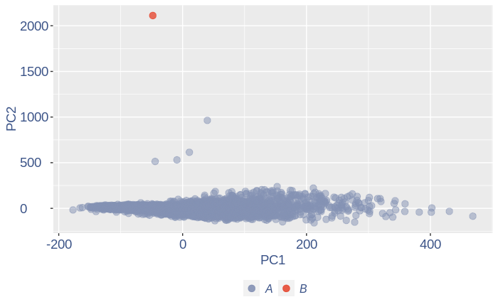

```r
obj = ttm$object

ttm$pca.cell.2
```

Run this when B cells need to be removed.

```r
pdf(paste(out_dir,"cleaning/",t,"_",n_it,"_plots_before_cells_exlusion.pdf", sep = ""))
ttm$pca.cell.2
ggplot(ttm$D, aes(x=n,y=means)) + geom_point() +
  geom_text_repel(data=subset(ttm$D, n > (max(ttm$D$n)- 15) ), aes(n,means,label=rownames(ttm$D[ttm$D$n > (max(ttm$D$n)- 15),])),
                  nudge_y      = 0.05,
                  nudge_x      = 0.05,
                  direction    = "x",
                  angle        = 90,
                  vjust        = 0,
                  segment.size = 0.2)+
  ggtitle("B cell group genes mean expression")+my_theme +
  theme(plot.title = element_text(color = "#3C5488FF", size = 20, face = "italic",vjust = - 5,hjust = 0.02 ))
```

```r
dev.off()
```

```r
if (length(ttm$cl1) < length(ttm$cl2)) {
  to_rem = ttm$cl1
}else{
  to_rem = ttm$cl2
}
n_it = n_it+1
obj@raw = obj@raw[,!colnames(obj@raw) %in% to_rem]
#obj@raw = obj@raw[rownames(obj@raw) %in% rownames(cells),colnames(obj@raw) %in% colnames(cells)]
gc()
```

```
             used   (Mb) gc trigger    (Mb)   max used    (Mb)
Ncells    7628094  407.4   12192210   651.2   12192210   651.2
Vcells 1052883345 8032.9 2548772766 19445.6 3982457446 30383.8
```

```r
ttm = clean(obj)
```

```
[1] "Start estimation mu with linear method"
[1] 14162  4778
```

|  | rowname | X10X83_2_GTGCGAGTGGAGTC. | X10X83_2_TCTCAGTAGAGGAA. | X10X83_3_CTCGCTCTGTCTCG. | X10X83_3_ACCAACAAATTGCC. |
| --- | --- | --- | --- | --- | --- |
| 5860 | Hba-a1 | 603.371341 | 1354.044610 | 671.4304617 | 553.155075 |
| 5862 | Hbb-bs | 579.635254 | 700.367902 | 666.8525267 | 524.000732 |
| 12603 | Tmsb4x | 148.587907 | 73.927723 | 115.9743525 | 59.474861 |
| 7189 | Malat1 | 49.845784 | 102.136986 | 74.0099486 | 64.917005 |
| 12599 | Tmsb10 | 58.865497 | 28.209263 | 43.4903822 | 49.368021 |
| 4626 | Fth1 | 99.691567 | 35.018395 | 24.4156532 | 15.937708 |
| 700 | Actb | 9.019713 | 28.209263 | 16.0227724 | 89.795378 |
| 5863 | Hbb-bt | 8.544991 | 43.772994 | 0.7629892 | 79.299814 |
| 5861 | Hba-a2 | 20.887757 | 52.527593 | 16.7857615 | 22.546026 |
| 2631 | Cldn5 | 57.441331 | 7.781866 | 41.2014147 | 0.000000 |

[output cut: 5 more lines]

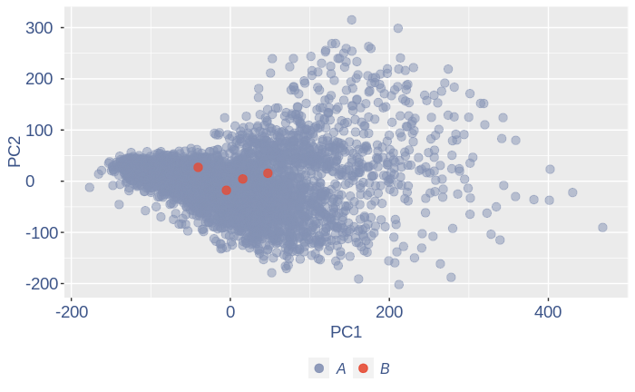

```r
#ttm = clean.sqrt(obj, cells)
obj = ttm$object

ttm$pca.cell.2
```

```
null device
          1
             used   (Mb) gc trigger    (Mb)   max used    (Mb)
Ncells    7628380  407.4   12192210   651.2   12192210   651.2
Vcells 1069627970 8160.7 2548772766 19445.6 3982457446 30383.8
[1] "Start estimation mu with linear method"
[1] 14147  4774
```

|  | rowname | X10X83_3_CATCTCATGAAGTA. |
| --- | --- | --- |
| 12959 | Ttr | 854.13561 |
| 7178 | Malat1 | 144.24771 |
| 10513 | Rpl41 | 40.67312 |
| 10560 | Rps23 | 35.94369 |
| 3758 | Eef1a1 | 29.79543 |
| 10566 | Rps27a | 26.01188 |
| 10547 | Rps14 | 24.12011 |
| 10482 | Rpl18a | 23.64717 |
| 10509 | Rpl37a | 23.64717 |
| 1810 | Bsg | 22.22834 |

[output cut: 5 more lines]

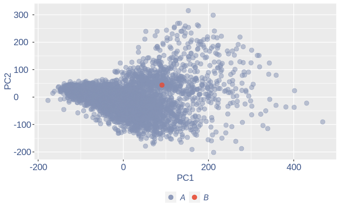

```
null device
          1
             used   (Mb) gc trigger    (Mb)   max used    (Mb)
Ncells    7628499  407.5   12192210   651.2   12192210   651.2
Vcells 1068820084 8154.5 2548772766 19445.6 3982457446 30383.8
[1] "Start estimation mu with linear method"
[1] 14143  4773
```

|  | rowname | X10X83_2_TTCTGAGTAGCCGA. | X10X83_2_TTGAAAGTCCGGTC. | X10X83_2_CAGTTAGCTAGGCA. | X10X83_2_CAATTAGGCCCTCA. | X10X83_2_GGGATGTTACTGAC. | X10X83_2_CGAAGGTAAACCTC. | X10X83_2_GAAGGAGTCGCCGT. | X10X83_2_ACCTTAGGGATACC. | X10X83_2_GACCTGTCTTGTCC. | X10X83_2_AACGAGTGTTCGAT. | X10X83_2_CCGAACACGGTGTC. | X10X83_2_CAGAAGTAAGTTCC. | X10X83_2_TATGCAGCTAGTCT. | X10X83_2_AGCCGGTCGAACAG. | X10X83_2_TTCCCCAGTACACT. | X10X83_2_ACCTCTCGACCAGC. | X10X83_2_GCGTTGTTGCGTTA. | X10X83_2_TAAGCTCCTAGGGC. | X10X83_2_TAGGCTCGGCGCAT. | X10X83_2_TGGCTCACTCAGGC. | X10X83_2_CTTCAGTATGAAAC. | X10X83_2_TCACTGTCTAAACC. | X10X83_2_CACGATCAATCACG. | X10X83_2_CGAAAGTTTAGCTG. | X10X83_2_CGGGTCAAGTCATC. | X10X83_2_AGTGAAGTTAAGTG. | X10X83_2_CGTCGGTAGTGAAT. | X10X83_2_CATCTTCTGAGTGT. | … |
| --- | --- | --- | --- | --- | --- | --- | --- | --- | --- | --- | --- | --- | --- | --- | --- | --- | --- | --- | --- | --- | --- | --- | --- | --- | --- | --- | --- | --- | --- | --- |
| 4136 | Fabp7 | 275.40317 | 134.199907 | 385.62404 | 209.428139 | 262.26683 | 222.41057 | 194.44733 | 353.603331 | 120.646849 | 301.66254 | 273.451720 | 172.61317 | 244.675951 | 365.744171 | 212.813620 | 295.86300 | 123.43190 | 337.80733 | 364.40724 | 156.708971 | 177.78995 | 353.523542 | 260.526175 | 195.74187 | 452.419536 | 266.55994 | 456.79845 | 251.650947 | … |
| 7175 | Malat1 | 68.08861 | 64.551854 | 61.69985 | 383.293010 | 76.38840 | 146.54960 | 116.66840 | 94.087436 | 151.968627 | 45.11668 | 128.826144 | 198.23543 | 193.753545 | 179.618134 | 0.000000 | 84.93008 | 105.14569 | 98.65170 | 109.07760 | 148.192179 | 198.50334 | 55.735694 | 164.244763 | 122.22380 | 136.012202 | 0.00000 | 60.28812 | 60.825584 | … |
| 2993 | Cst3 | 38.61742 | 4.246832 | 27.54457 | 57.296378 | 37.34544 | 49.99928 | 38.88947 | 19.644630 | 17.400988 | 71.65591 | 29.168184 | 24.27373 | 70.794565 | 81.999583 | 102.465817 | 46.64193 | 48.76322 | 46.33640 | 50.38114 | 122.641803 | 75.94910 | 65.290384 | 152.917538 | 26.65030 | 75.880492 | 33.00266 | 41.73793 | 8.348610 | … |
| 3204 | Dbi | 42.68241 | 31.426560 | 57.29271 | 33.587532 | 41.58924 | 62.06807 | 26.51554 | 41.357115 | 32.481844 | 57.50166 | 34.029547 | 41.80475 | 53.406426 | 84.602744 | 43.350923 | 36.89586 | 56.38247 | 29.89445 | 52.82682 | 59.617543 | 18.98728 | 55.735694 | 77.402704 | 41.35392 | 50.109759 | 50.77332 | 44.05670 | 32.201780 | … |
| 1150 | Apoe | 27.43869 | 22.083529 | 53.98737 | 51.369166 | 28.85784 | 15.51702 | 38.88947 | 17.576774 | 6.960395 | 34.50099 | 35.244888 | 25.62227 | 79.488634 | 52.063227 | 126.111775 | 38.28815 | 77.71638 | 83.70447 | 81.68592 | 54.507468 | 120.82812 | 47.773452 | 50.972513 | 17.46054 | 57.268296 | 15.23200 | 59.12873 | 9.541268 | … |
| 12586 | Tmsb4x | 67.07236 | 34.824026 | 70.51411 | 39.514743 | 42.43800 | 60.34395 | 53.03109 | 61.001744 | 18.561054 | 58.38630 | 25.522161 | 37.75913 | 29.808238 | 49.460066 | 59.114894 | 80.05705 | 19.81006 | 35.87334 | 33.26133 | 35.770526 | 29.34397 | 52.550797 | 28.318063 | 105.68223 | 37.224392 | 27.92533 | 60.28812 | 54.862292 | … |
| 9767 | Ptn | 30.48744 | 29.727827 | 24.23923 | 29.636057 | 65.35452 | 62.06807 | 22.98014 | 20.678557 | 100.925730 | 42.46276 | 29.168184 | 47.19891 | 31.050248 | 23.428452 | 55.173901 | 50.12267 | 143.24196 | 35.87334 | 57.22906 | 28.957092 | 44.87902 | 41.403658 | 15.102967 | 53.30060 | 48.678051 | 50.77332 | 35.94099 | 26.238487 | … |
| 10509 | Rpl41 | 24.38995 | 26.330361 | 17.62853 | 21.733109 | 26.31156 | 17.24113 | 28.28325 | 24.814269 | 42.922437 | 30.07779 | 26.737502 | 32.36497 | 26.082208 | 15.618968 | 45.321419 | 22.27674 | 32.00086 | 10.46306 | 26.90255 | 15.330225 | 20.71339 | 30.256519 | 18.878708 | 14.70362 | 11.453659 | 30.46399 | 37.10038 | 29.816463 | … |
| 10550 | Rps19 | 25.40620 | 41.618958 | 18.73031 | 15.805897 | 22.91652 | 24.13758 | 38.88947 | 26.882125 | 42.922437 | 10.61569 | 18.230115 | 20.22811 | 19.872158 | 11.714226 | 47.291916 | 27.84593 | 21.33391 | 16.44195 | 28.36996 | 22.143659 | 20.71339 | 23.886726 | 18.878708 | 21.13645 | 10.021952 | 45.69599 | 24.34713 | 29.816463 | … |
| 10470 | Rpl13 | 16.25997 | 33.974660 | 18.73031 | 3.951474 | 22.91652 | 17.24113 | 35.35406 | 25.848197 | 44.082503 | 17.69282 | 25.522161 | 25.62227 | 18.630149 | 13.015807 | 31.527944 | 18.09985 | 25.90546 | 11.95778 | 28.85910 | 13.626867 | 24.16562 | 22.294277 | 15.102967 | 26.65030 | 17.180489 | 45.69599 | 19.70958 | 16.697219 | … |

[output cut: 5 more lines]

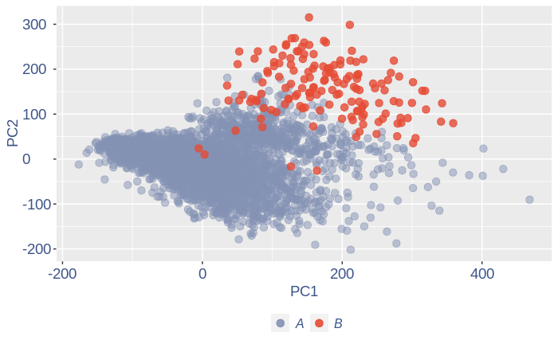

Run this only in the last iteration, instead the previous code, when B cells group has not to be removed.

```r
pdf(paste(out_dir,"cleaning/",t,"_",n_it,"_plots_before_cells_exlusion.pdf", sep = ""))
ttm$pca.cell.2
ggplot(ttm$D, aes(x=n,y=means)) + geom_point() +
  geom_text_repel(data=subset(ttm$D, n > (max(ttm$D$n)- 15) ), aes(n,means,label=rownames(ttm$D[ttm$D$n > (max(ttm$D$n)- 15),])),
                  nudge_y      = 0.05,
                  nudge_x      = 0.05,
                  direction    = "x",
                  angle        = 90,
                  vjust        = 0,
                  segment.size = 0.2)+
  ggtitle(label = "B cell group genes mean expression", subtitle = " - B group NOT removed -")+my_theme +
  theme(plot.title = element_text(color = "#3C5488FF", size = 20, face = "italic",vjust = - 10,hjust = 0.02 ),
        plot.subtitle = element_text(color = "darkred",vjust = - 15,hjust = 0.01 ))
```

```r
dev.off()
```

To colour the pca based on nu_j (so the cells’ efficiency).

```r
nu_est = round(obj@nu, digits = 7)

plot.nu <-ggplot(ttm$pca_cells,aes(x=PC1,y=PC2, colour = log(nu_est)))

plot.nu = plot.nu + geom_point(size = 1,alpha= 0.8)+
  scale_color_gradient2(low = "#E64B35B2",mid =  "#4DBBD5B2", high =  "#3C5488B2" ,
                        midpoint = log(mean(nu_est)),name = "ln (nu)")+
  ggtitle("Cells PCA coloured by cells efficiency") +
  my_theme +  theme(plot.title = element_text(color = "#3C5488FF", size = 20),
                    legend.title=element_text(color = "#3C5488FF", size = 14,face = "italic"),
                    legend.text = element_text(color = "#3C5488FF", size = 11),
                    legend.key.width = unit(2, "mm"),
                    legend.position="right")

pdf(paste(out_dir,"cleaning/",t,"_plots_PCA_efficiency_colored.pdf", sep = ""))
plot.nu
dev.off()
```

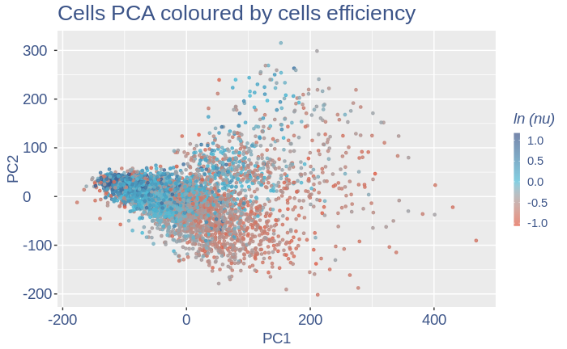

```r
plot.nu
```

The next part is used to remove the cells with efficiency too low.

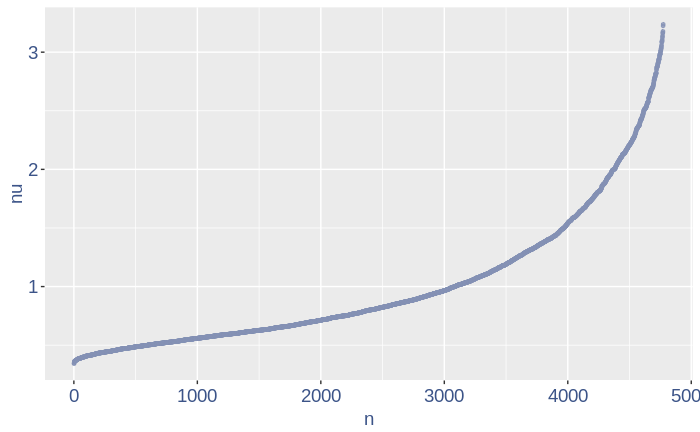

```r
nu_df = data.frame("nu"= sort(obj@nu), "n"=c(1:length(obj@nu)))

ggplot(nu_df, aes(x = n, y=nu)) +
    geom_point(colour = "#8491B4B2", size=1)+
    my_theme #+ ylim(0,1) + xlim(0,70)
```

We can zoom on the smallest values and, if we detect a clear elbow, we can decide to remove the cells.

```r
yset = 0.4#threshold to remove low UDE cells
plot.ude <- ggplot(nu_df, aes(x = n, y=nu)) +
    geom_point(colour = "#8491B4B2", size=1) +
    my_theme + ylim(0.,0.7) + xlim(0,2000) +
    geom_hline(yintercept=yset, linetype="dashed", color = "darkred") +
    annotate(geom="text", x=500, y=0.5,
             label=paste("to remove cells with nu < ",yset,sep = " "),
             color="darkred", size=4.5)


pdf(paste(out_dir,"cleaning/",t,"_plots_efficiency.pdf", sep = ""))
plot.ude
dev.off()
```

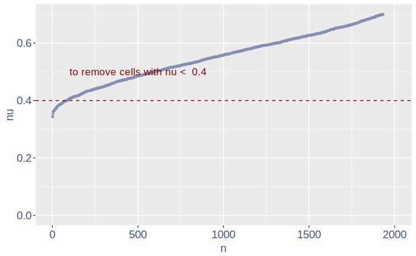

```r
plot.ude
```

We also save the defined threshold in the metadata and re-run the estimation.

```r
obj@meta[(nrow(obj@meta)+1),1:2] = c("Threshold low UDE cells:",yset)

to_rem = rownames(nu_df[which(nu_df$nu < yset),])

obj@raw = obj@raw[, !colnames(obj@raw) %in% to_rem]
```

Repeat the estimation after the cells are removed

```r
ttm = clean(obj)
```

```
[1] "Start estimation mu with linear method"
[1] 14121  4690
```

|  | rowname | X10X83_2_TTCTGAGTAGCCGA. | X10X83_2_TTGAAAGTCCGGTC. | X10X83_2_CAGTTAGCTAGGCA. | X10X83_2_CAATTAGGCCCTCA. | X10X83_2_GGGATGTTACTGAC. | X10X83_2_CGAAGGTAAACCTC. | X10X83_2_GAAGGAGTCGCCGT. | X10X83_2_ACCTTAGGGATACC. | X10X83_2_AACGAGTGTTCGAT. | X10X83_2_CCGAACACGGTGTC. | X10X83_2_CAGAAGTAAGTTCC. | X10X83_2_GGAGAGTTTACTCT. | X10X83_2_TATGCAGCTAGTCT. | X10X83_2_AGCCGGTCGAACAG. | X10X83_2_TTCCCCAGTACACT. | X10X83_2_ACCTCTCGACCAGC. | X10X83_2_TAAGCTCCTAGGGC. | X10X83_2_TAGGCTCGGCGCAT. | X10X83_2_TGGCTCACTCAGGC. | X10X83_2_CTTCAGTATGAAAC. | X10X83_2_TCACTGTCTAAACC. | X10X83_2_CACGATCAATCACG. | X10X83_2_CGAAAGTTTAGCTG. | X10X83_2_CGGGTCAAGTCATC. | X10X83_2_GTCTGTCGAGAACG. | X10X83_2_CGTCGGTAGTGAAT. | X10X83_2_CATCTTCTGAGTGT. | X10X83_2_CAGTTGTTAAGAAC. | … |
| --- | --- | --- | --- | --- | --- | --- | --- | --- | --- | --- | --- | --- | --- | --- | --- | --- | --- | --- | --- | --- | --- | --- | --- | --- | --- | --- | --- | --- | --- | --- |
| 4130 | Fabp7 | 278.40788 | 135.68345 | 389.83129 | 211.713051 | 265.12823 | 224.90237 | 196.56879 | 357.523428 | 304.95375 | 276.435145 | 174.49642 | 148.59319 | 247.345425 | 369.734529 | 215.135468 | 299.09093 | 341.49289 | 368.38301 | 158.50957 | 179.72968 | 357.380570 | 263.368579 | 197.87747 | 457.355543 | 161.89321 | 461.78223 | 254.396520 | 314.99484 | … |
| 7161 | Malat1 | 68.83147 | 65.26546 | 62.37301 | 387.474829 | 77.22181 | 148.19148 | 117.94128 | 95.130503 | 45.60892 | 130.231668 | 200.39823 | 132.95180 | 195.867443 | 181.577811 | 0.000000 | 85.85669 | 99.72801 | 110.26767 | 149.89492 | 200.66906 | 56.343783 | 166.036713 | 123.55729 | 137.496128 | 135.99030 | 60.94588 | 61.489206 | 191.29242 | … |
| 2989 | Cst3 | 39.03874 | 4.29378 | 27.84509 | 57.921495 | 37.75289 | 50.55945 | 39.31376 | 19.862413 | 72.43769 | 29.486415 | 24.53856 | 53.18072 | 71.566950 | 82.894218 | 103.583744 | 47.15081 | 46.84194 | 50.93081 | 124.05096 | 76.77773 | 66.002718 | 154.585905 | 26.94106 | 76.708366 | 43.71117 | 42.19330 | 8.439695 | 66.31470 | … |
| 3200 | Dbi | 43.14808 | 31.77397 | 57.91779 | 33.953980 | 42.04299 | 62.76345 | 26.80484 | 41.815606 | 58.12901 | 34.400818 | 42.26085 | 32.84691 | 53.989103 | 85.525781 | 43.823892 | 37.29840 | 30.22061 | 53.40317 | 60.30255 | 19.19443 | 56.343783 | 78.247186 | 41.80510 | 50.656468 | 77.70874 | 44.53737 | 32.553109 | 43.35961 | … |
| 1147 | Apoe | 27.73805 | 22.32766 | 54.57638 | 51.929616 | 29.17269 | 15.69086 | 39.31376 | 17.771632 | 34.87741 | 35.629419 | 25.90181 | 23.46208 | 80.355874 | 52.631250 | 127.487685 | 38.70589 | 84.61771 | 82.57713 | 55.13376 | 122.14638 | 48.294672 | 51.528635 | 17.65104 | 57.893107 | 11.33252 | 59.77384 | 9.645366 | 109.67432 | … |
| 12565 | Tmsb4x | 67.80413 | 35.20900 | 71.28344 | 39.945859 | 42.90101 | 61.02002 | 53.60967 | 61.678018 | 59.02331 | 25.800613 | 38.17109 | 40.66761 | 30.133453 | 49.999687 | 59.759852 | 80.93049 | 36.26473 | 33.62422 | 36.18153 | 29.66412 | 53.124139 | 28.627019 | 106.83525 | 37.630519 | 11.33252 | 60.94588 | 55.460853 | 38.25848 | … |
| 9749 | Ptn | 30.82006 | 30.05646 | 24.50368 | 29.959394 | 66.06755 | 62.76345 | 23.23086 | 20.907803 | 42.92604 | 29.486415 | 47.71386 | 26.59036 | 31.389013 | 23.684062 | 55.775862 | 50.66952 | 36.26473 | 57.85344 | 29.28981 | 45.36866 | 41.855382 | 15.267744 | 53.88213 | 49.209141 | 22.66505 | 36.33312 | 26.524756 | 54.83716 | … |
| 10491 | Rpl41 | 24.65605 | 26.62144 | 17.82086 | 21.970222 | 26.59862 | 17.43429 | 28.59182 | 25.089363 | 30.40595 | 27.029214 | 32.71808 | 23.46208 | 26.366771 | 15.789375 | 45.815887 | 22.51979 | 10.57721 | 27.19606 | 15.50637 | 20.93938 | 30.586625 | 19.084680 | 14.86403 | 11.578621 | 27.52185 | 37.50516 | 30.141768 | 16.57868 | … |
| 10452 | Rpl13 | 16.43737 | 34.35024 | 18.93466 | 3.994586 | 23.16654 | 17.43429 | 35.73978 | 26.134754 | 17.88585 | 25.800613 | 25.90181 | 31.28278 | 18.833408 | 13.157812 | 31.871921 | 18.29733 | 12.08824 | 29.17396 | 13.78344 | 24.42928 | 22.537513 | 15.267744 | 26.94106 | 17.367932 | 25.90291 | 19.92461 | 16.879390 | 12.75283 | … |
| 10532 | Rps19 | 25.68338 | 42.07905 | 18.93466 | 15.978343 | 23.16654 | 24.40801 | 39.31376 | 27.180144 | 10.73151 | 18.429010 | 20.44880 | 26.59036 | 20.088969 | 11.842031 | 47.807882 | 28.14973 | 16.62134 | 28.67948 | 22.39809 | 20.93938 | 24.147336 | 19.084680 | 21.36705 | 10.131294 | 25.90291 | 24.61276 | 30.141768 | 15.30339 | … |

[output cut: 5 more lines]

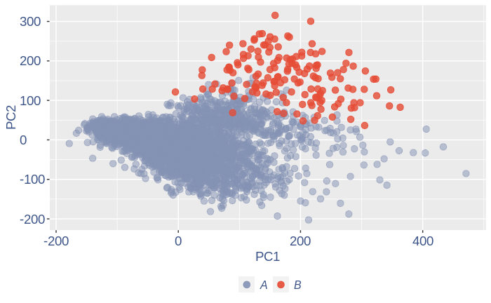

```r
obj = ttm$object
ttm$pca.cell.2
```

Just to check again, we plot the final efficiency coloured PCA.

```r
nu_est = round(obj@nu, digits = 7)
plot.nu <-ggplot(ttm$pca_cells,aes(x=PC1,y=PC2, colour = log(nu_est)))
plot.nu = plot.nu + geom_point(size = 2,alpha= 0.8)+
  scale_color_gradient2(low = "#E64B35B2",mid =  "#4DBBD5B2", high =  "#3C5488B2" ,
                        midpoint = log(mean(nu_est)),name = "ln(nu)")+
  ggtitle("Cells PCA coloured by cells efficiency: last") +
  my_theme +  theme(plot.title = element_text(color = "#3C5488FF", size = 20),
                    legend.title=element_text(color = "#3C5488FF", size = 14,face = "italic"),
                    legend.text = element_text(color = "#3C5488FF", size = 11),
                    legend.key.width = unit(2, "mm"),
                    legend.position="right")

pdf(paste(out_dir,"cleaning/",t,"_plots_PCA_efficiency_colored_FINAL.pdf", sep = ""))
plot.nu
dev.off()
```

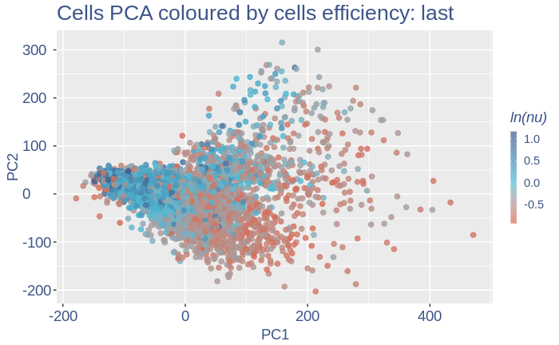

```r
plot.nu
```

COTAN analysis: in this part all the contingency tables are computed and used to get the statistics (S) To storage efficiency of all the observed tables only the yes_yes is stored. Note that if will be necessary re-computing the yes-yes table, the yes-yes table should be cancelled before running cotan_analysis.

```r
# obj@yes_yes = c()
obj = cotan_analysis(obj)
```

COEX evaluation and storing

```r
saveRDS(obj,file = paste(out_dir,t,".cotan.RDS", sep = ""))

obj = get.coex(obj)

# saving the structure
saveRDS(obj,file = paste(out_dir,t,".cotan.RDS", sep = ""))
```

Automatic data elaboration (without cleaning)

```r
obj2 = automatic.COTAN.object.creation(df = data,GEO="GSE104323" ,sc.method="10X",cond = "P0_dent_gyrus",
                                       out_dir =  "Data/")
```

# 3 Analysis of the elaborated data

In this case the test possible macroscopic differences between cleaned and not cleaned data.

The initial cell number was:

```r
obj@meta
```

```
Object of class "data.frame"
```

|  | V1 | V2 |
| --- | --- | --- |
| 1 | GEO: | GSE104323 |
| 2 | scRNAseq method: | 10X |
| 3 | starting n. of cells: | 4779 |
| 4 | Condition sample: | mouse dentate gyrus P0 |
| 5 | Threshold low UDE cells: | 0.4 |

While the final number of cells was:

```r
ncol(obj@raw)
```

```
[1] 4690
```

So were removed:

```r
as.numeric(obj@meta[3,2]) - ncol(obj@raw)
```

```
[1] 89
```

cells

## 3.1 GDI with cleaning

```r
quant.p = get.GDI(obj)
```

```
[1] "function to generate GDI dataframe"
[1] "Using S"
[1] "function to generate S "
```

```r
head(quant.p)
```

|  | sum.raw.norm | GDI | exp.cells |
| --- | --- | --- | --- |
| 0610007P14Rik | 8.538538 | 2.909430 | 58.635394 |
| 0610009B22Rik | 7.788376 | 2.044579 | 37.270789 |
| 0610009L18Rik | 6.464229 | 1.809001 | 12.366738 |
| 0610009O20Rik | 6.279491 | 1.787471 | 9.616205 |
| 0610010F05Rik | 7.952439 | 3.657138 | 41.300640 |
| 0610010K14Rik | 7.650414 | 2.042570 | 33.731343 |

In the third column of this dataframe is reported the percentage of cells expressing the gene.

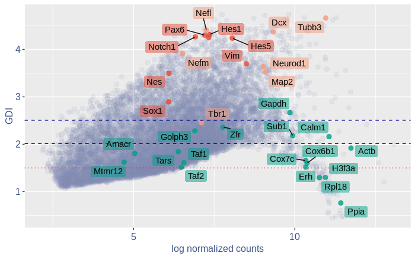

```r
NPGs=c("Nes","Vim","Sox2","Sox1","Notch1", "Hes1","Hes5","Pax6") #,"Hes3"
PNGs=c("Map2","Tubb3","Neurod1","Nefm","Nefl","Dcx","Tbr1")
hk=c("Calm1","Cox6b1","Ppia","Rpl18","Cox7c","Erh","H3f3a","Taf1","Taf2","Gapdh","Actb","Golph3", "Mtmr12", "Zfr", "Sub1", "Tars", "Amacr")

text.size = 12

quant.p$highlight = with(quant.p, ifelse(rownames(quant.p) %in% NPGs, "NPGs",
                                                 ifelse(rownames(quant.p) %in% hk,"Constitutive" ,
                                                               ifelse(rownames(quant.p) %in% PNGs,"PNGs" , "normal"))))

textdf <- quant.p[rownames(quant.p) %in% c(NPGs,hk,PNGs), ]
mycolours <- c("Constitutive" = "#00A087FF","NPGs"="#E64B35FF","PNGs"="#F39B7FFF","normal" = "#8491B4B2")
f1 = ggplot(subset(quant.p,highlight == "normal" ), aes(x=sum.raw.norm, y=GDI)) +  geom_point(alpha = 0.1, color = "#8491B4B2", size=2.5)
GDI_plot = f1 +  geom_point(data = subset(quant.p,highlight != "normal"  ), aes(x=sum.raw.norm, y=GDI, colour=highlight),size=2.5,alpha = 0.8) +
  geom_hline(yintercept=quantile(quant.p$GDI)[4], linetype="dashed", color = "darkblue") +
  geom_hline(yintercept=quantile(quant.p$GDI)[3], linetype="dashed", color = "darkblue") +
  geom_hline(yintercept=1.5, linetype="dotted", color = "red", size= 0.5) +
  scale_color_manual("Status", values = mycolours)  +
  scale_fill_manual("Status", values = mycolours)  +
  xlab("log normalized counts")+ylab("GDI")+
  geom_label_repel(data =textdf , aes(x=sum.raw.norm, y=GDI, label = rownames(textdf),fill=highlight),
                   label.size = NA,
                   alpha = 0.5,
                   direction ="both",
                   na.rm=TRUE,
                   seed = 1234) +
  geom_label_repel(data =textdf , aes(x=sum.raw.norm, y=GDI, label = rownames(textdf)),
                   label.size = NA,
                   segment.color = 'black',
                   segment.size = 0.5,
                   direction = "both",
                   alpha = 0.8,
                   na.rm=TRUE,
                   fill = NA,
                   seed = 1234) +
  theme(axis.text.x = element_text(size = text.size, angle = 0, hjust = .5, vjust = .5, face = "plain", colour ="#3C5488FF" ),
        axis.text.y = element_text( size = text.size, angle = 0, hjust = 0, vjust = .5, face = "plain", colour ="#3C5488FF"),
        axis.title.x = element_text( size = text.size, angle = 0, hjust = .5, vjust = 0, face = "plain", colour ="#3C5488FF"),
        axis.title.y = element_text( size = text.size, angle = 90, hjust = .5, vjust = .5, face = "plain", colour ="#3C5488FF"),
        legend.title = element_blank(),
        legend.text = element_text(color = "#3C5488FF",face ="italic" ),
        legend.position = "bottom")  # titl)
legend <- cowplot::get_legend(GDI_plot)
GDI_plot =GDI_plot + theme(
        legend.position = "none")
GDI_plot
```

## 3.2 GDI without cleaning

```r
quant.p = get.GDI(obj2)
```

```
[1] "function to generate GDI dataframe"
[1] "Using S"
[1] "function to generate S "
```

```r
head(quant.p)
```

|  | sum.raw.norm | GDI | exp.cells |
| --- | --- | --- | --- |
| 0610007P14Rik | 8.545662 | 2.930231 | 58.108391 |
| 0610009B22Rik | 7.803461 | 2.049402 | 37.057962 |
| 0610009L18Rik | 6.474749 | 1.819495 | 12.220130 |
| 0610009O20Rik | 6.299620 | 1.809639 | 9.583595 |
| 0610010F05Rik | 7.965502 | 3.652991 | 40.929065 |
| 0610010K14Rik | 7.656849 | 2.033830 | 33.417033 |

In the third column of this dataframe is reported the percentage of cells expressing the gene.

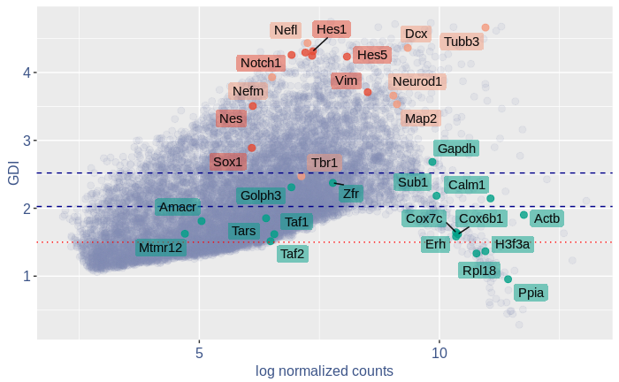

```r
NPGs=c("Nes","Vim","Sox2","Sox1","Notch1", "Hes1","Hes5","Pax6") #,"Hes3"
PNGs=c("Map2","Tubb3","Neurod1","Nefm","Nefl","Dcx","Tbr1")
hk=c("Calm1","Cox6b1","Ppia","Rpl18","Cox7c","Erh","H3f3a","Taf1","Taf2","Gapdh","Actb","Golph3", "Mtmr12", "Zfr", "Sub1", "Tars", "Amacr")

text.size = 12

quant.p$highlight = with(quant.p, ifelse(rownames(quant.p) %in% NPGs, "NPGs",
                                                 ifelse(rownames(quant.p) %in% hk,"Constitutive" ,
                                                               ifelse(rownames(quant.p) %in% PNGs,"PNGs" , "normal"))))

textdf <- quant.p[rownames(quant.p) %in% c(NPGs,hk,PNGs), ]
mycolours <- c("Constitutive" = "#00A087FF","NPGs"="#E64B35FF","PNGs"="#F39B7FFF","normal" = "#8491B4B2")
f1 = ggplot(subset(quant.p,highlight == "normal" ), aes(x=sum.raw.norm, y=GDI)) +  geom_point(alpha = 0.1, color = "#8491B4B2", size=2.5)
GDI_plot = f1 +  geom_point(data = subset(quant.p,highlight != "normal"  ), aes(x=sum.raw.norm, y=GDI, colour=highlight),size=2.5,alpha = 0.8) +
  geom_hline(yintercept=quantile(quant.p$GDI)[4], linetype="dashed", color = "darkblue") +
  geom_hline(yintercept=quantile(quant.p$GDI)[3], linetype="dashed", color = "darkblue") +
  geom_hline(yintercept=1.5, linetype="dotted", color = "red", size= 0.5) +
  scale_color_manual("Status", values = mycolours)  +
  scale_fill_manual("Status", values = mycolours)  +
  xlab("log normalized counts")+ylab("GDI")+
  geom_label_repel(data =textdf , aes(x=sum.raw.norm, y=GDI, label = rownames(textdf),fill=highlight),
                   label.size = NA,
                   alpha = 0.5,
                   direction ="both",
                   na.rm=TRUE,
                   seed = 1234) +
  geom_label_repel(data =textdf , aes(x=sum.raw.norm, y=GDI, label = rownames(textdf)),
                   label.size = NA,
                   segment.color = 'black',
                   segment.size = 0.5,
                   direction = "both",
                   alpha = 0.8,
                   na.rm=TRUE,
                   fill = NA,
                   seed = 1234) +
  theme(axis.text.x = element_text(size = text.size, angle = 0, hjust = .5, vjust = .5, face = "plain", colour ="#3C5488FF" ),
        axis.text.y = element_text( size = text.size, angle = 0, hjust = 0, vjust = .5, face = "plain", colour ="#3C5488FF"),
        axis.title.x = element_text( size = text.size, angle = 0, hjust = .5, vjust = 0, face = "plain", colour ="#3C5488FF"),
        axis.title.y = element_text( size = text.size, angle = 90, hjust = .5, vjust = .5, face = "plain", colour ="#3C5488FF"),
        legend.title = element_blank(),
        legend.text = element_text(color = "#3C5488FF",face ="italic" ),
        legend.position = "bottom")  # titl)
legend <- cowplot::get_legend(GDI_plot)
GDI_plot =GDI_plot + theme(
        legend.position = "none")
GDI_plot
```

## 3.3 Heatmaps with cleaning

```
[1] "plot heatmap"
[1] "Loading condition P0_dent_cleaned"
[1] "Map2"    "Tubb3"   "Neurod1" "Nefm"    "Nefl"    "Dcx"     "Tbr1"
[1] "Get p-values on a set of genes on columns on a set of genes on rows"
[1] "Using function S"
[1] "function to generate S "
[1] "Ref.col"
[1] "NPGs"
[1] "Const."
[1] "min coex: -0.00753159172756036 max coex 0.00674563579291443"
```

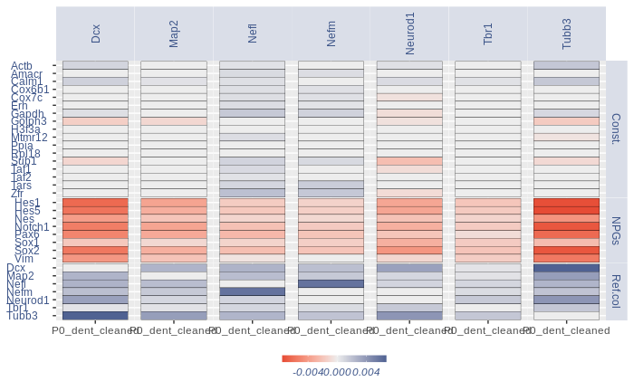

```r
list.genes = list("Ref.col"= PNGs, "NPGs"=NPGs, "Const."=hk )

plot.heatmap(df_genes = list.genes,sets = c(1:3),conditions = "P0_dent_cleaned",dir = "Data/")
```

## 3.4 Heatmaps without cleaning

```
[1] "plot heatmap"
[1] "Loading condition P0_dent_gyrus"
[1] "Map2"    "Tubb3"   "Neurod1" "Nefm"    "Nefl"    "Dcx"     "Tbr1"
[1] "Get p-values on a set of genes on columns on a set of genes on rows"
[1] "Using function S"
[1] "function to generate S "
[1] "Ref.col"
[1] "NPGs"
[1] "Const."
[1] "min coex: -0.00741399939021704 max coex 0.00658383694600149"
```

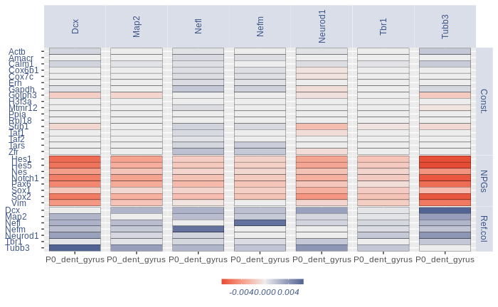

```r
list.genes = list("Ref.col"= PNGs, "NPGs"=NPGs, "Const."=hk )

plot.heatmap(df_genes = list.genes,sets = c(1:3),conditions = "P0_dent_gyrus",dir = "Data/")
```